# Supplemental Oxygen, Altitude, and Himalayan Expedition Success

STAT 3302: Statistical Modeling for Discovery II

Authors

Steven Dahms

Bardaan Dhesi

Kritarsh Negi

Published

April 29, 2026

## Abstract

We studied whether supplemental oxygen and peak height predict the probability that a Himalayan expedition successfully reaches a summit. Using 882 expeditions from 2020-2024, we fit a logistic regression model with oxygen use, centered peak height, a quadratic height term, season, number of high camps, team size, and an oxygen-by-height interaction. The model shows that oxygen use is strongly associated with summit success, and the oxygen advantage becomes much larger as peak height increases.

## Introduction

Himalayan climbing is a high-risk activity where weather, altitude, preparation, team size, and expedition strategy all affect the chance of success. Our main research question is: what factors predict whether an expedition successfully summits a Himalayan peak? We are especially interested in whether the effect of supplemental oxygen depends on peak height.

This interaction is scientifically motivated. As altitude increases, lower oxygen availability makes movement and decision-making more difficult. If supplemental oxygen is useful, it should be most useful on the tallest peaks, where hypoxia is most severe. At the same time, very high peaks may attract more prepared and better-funded teams, so the raw relationship between height and success may not be a simple downward trend.

## Data

The data come from the Himalayan Database through the 2025-01-21 TidyTuesday release. The unit of observation is one expedition. The analysis uses 882 expeditions from 2020-2024 across 116 distinct peaks. The response variable is `SUCCESS`, coded 1 when `TERMREASON` indicates success on the main peak, subpeak, foresummit, or a claimed success, and 0 otherwise.

The overall success rate was 74.1%. Peak heights in the model ranged from 5608 to 8849 meters, with an average of 7.76 km. Oxygen use is not randomly assigned: expeditions using oxygen were generally on taller peaks, so we control for peak height directly in the model.

Table 1: Expedition outcomes by supplemental oxygen use.

| Oxygen used | Expeditions | Success rate | Average height (km) |
| --- | --- | --- | --- |
| No | 473 | 56.7% | 7.11 |
| Yes | 409 | 94.4% | 8.52 |

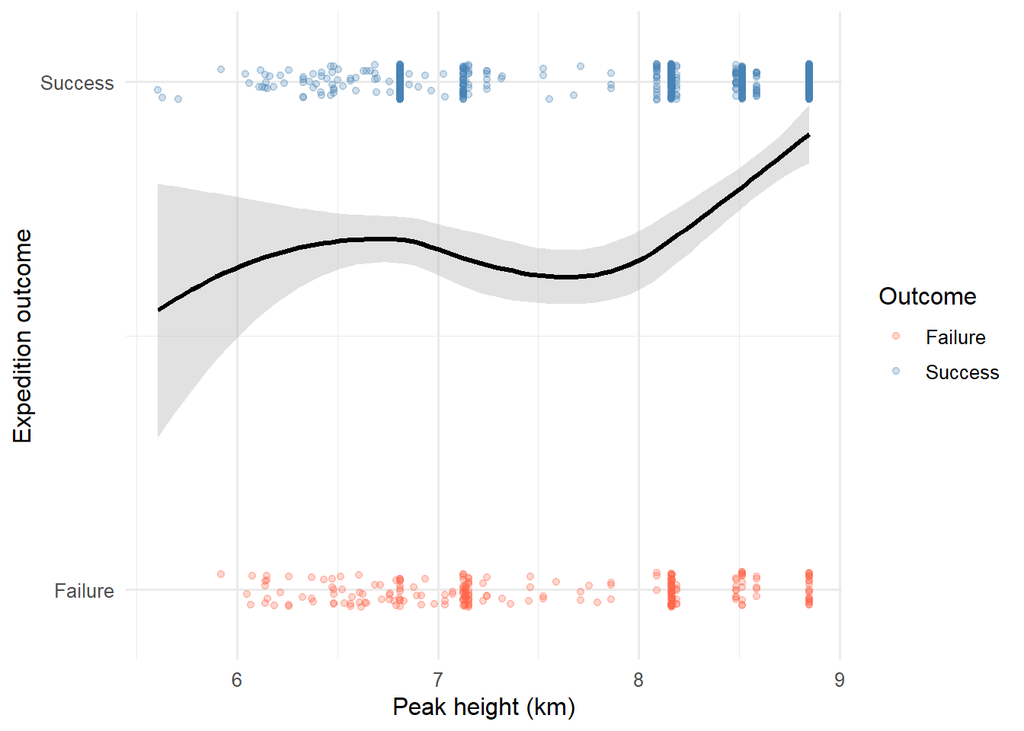

Figure 1: Initial height-success plot with individual expedition outcomes and a LOESS smooth.

This initial plot shows why a straight-line height effect is too simple. The individual dots show each expedition at the failure and success margins, while the smooth curve suggests a non-linear pattern: success drops at some high altitudes but rises again among the tallest peaks. One plausible explanation is self-selection, since the tallest peaks tend to be attempted by more experienced, better-funded, and more prepared teams.

## Methods

Because the response is binary, we model expedition success as a Bernoulli outcome using logistic regression with a logit link. Let $\pi_i$ be the probability that expedition $i$ succeeds. The fitted model is

$$\log\left(\frac{\pi_i}{1-\pi_i}\right) =
\beta_0 + \beta_1 O2_i + \beta_2 H_i + \beta_3 H_i^2 +
\beta_4(O2_iH_i) + \beta_5 Season_i + \beta_6 Camps_i +
\beta_7 TeamSize_i,$$

where $H_i$ is peak height in kilometers, centered at the sample mean. Height was converted from meters to kilometers so a one-unit change is meaningful, and it was centered to make the intercept and interaction more stable. We included a quadratic height term because the initial height-success plot bends rather than following a constant upward or downward slope. In context, that pattern is reasonable: very tall peaks are more dangerous, but they also attract more selective teams. A likelihood ratio test confirms that the quadratic term improves fit compared with the same model without it ($p = 0.005$).

The main term of interest is `O2USED:HEIGHTM_KM_C`, which tests whether the association between supplemental oxygen and success changes as peaks get taller. We compare this model to an additive model without the interaction using a likelihood ratio test.

## Results

Table 2: Odds ratios from the fitted logistic regression model.

| Predictor | OR | 95% Wald CI | p-value |
| --- | --- | --- | --- |
| Oxygen used | 14.53 | 6.07 to 34.77 | 1.83e-09 |
| Height, centered km | 0.09 | 0.05 to 0.17 | 7.77e-13 |
| Height squared | 0.53 | 0.34 to 0.83 | 0.006 |
| Spring vs Autumn | 0.59 | 0.37 to 0.93 | 0.023 |
| Summer vs Autumn | 0.97 | 0.15 to 6.51 | 0.976 |
| Winter vs Autumn | 0.88 | 0.28 to 2.72 | 0.825 |
| High camps | 1.77 | 1.48 to 2.10 | 1.38e-10 |
| Team members | 1.10 | 1.06 to 1.15 | 5.47e-06 |
| Oxygen x height | 27.85 | 7.81 to 99.30 | 2.92e-07 |

At the centered height value, oxygen use is associated with much higher odds of success (OR = 14.53, 95% CI 6.07 to 34.77). The centered height term is negative (OR = 0.09), while the quadratic term is also significant, confirming that the height effect is not constant over the range of the data.

The interaction between oxygen use and height is positive and significant (OR = 27.85, $p = 2.92e-07$). The likelihood ratio test comparing the additive model to the interaction model also supports keeping the interaction ($p = 4.76e-06$); AIC drops from 674.58 to 655.65. This means the estimated oxygen advantage increases sharply as peak height increases.

High camps and team size were also positively associated with success. Each additional high camp multiplies the odds of success by about 1.77, and each additional team member multiplies the odds by about 1.10. After controlling for the other predictors, Spring expeditions have lower odds of success than Autumn expeditions.

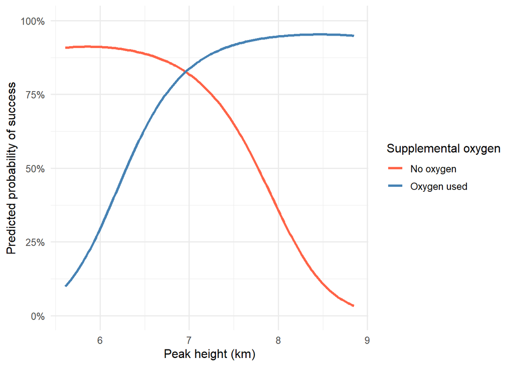

Figure 2: Predicted summit success probability by peak height and oxygen use, holding season at Autumn and numeric controls at their sample means.

## Diagnostics

We checked residual plots rather than relying only on a calibration plot. For logistic regression, residuals do not need to be normally distributed, but they should be centered around zero without a strong trend across fitted probabilities. The Pearson dispersion estimate was 1.06, which does not suggest serious overdispersion.

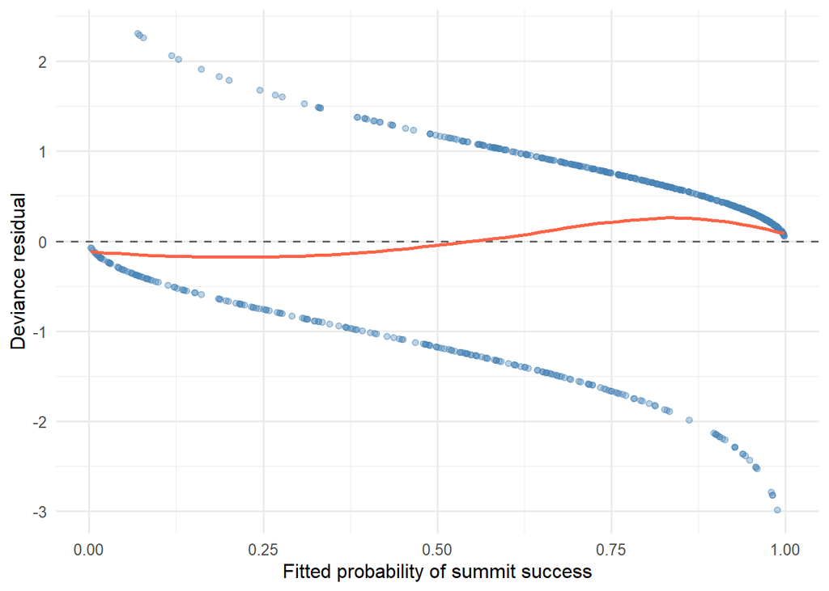

Figure 3: Deviance residuals plotted against fitted summit-success probabilities.

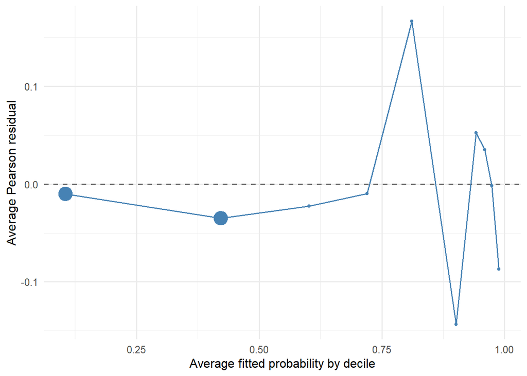

Figure 4: Average Pearson residual by fitted-probability decile.

## Discussion

The results support the central hypothesis: supplemental oxygen is not only associated with higher summit success overall, but its association with success is stronger on taller peaks. This matches the physiological motivation that oxygen matters more when altitude-related hypoxia is more severe.

The findings should not be interpreted as a randomized causal effect. Teams choose whether to use oxygen, and that choice is related to peak height, resources, experience, route difficulty, and expedition goals. We controlled for height, season, camps, and team size, but the dataset does not fully capture climber skill, weather severity, budget, Sherpa support, or route-level technical difficulty. There may also be repeated dependence among expeditions on the same popular peaks, especially Mount Everest and other 8000-meter peaks.

With more time, we would extend the analysis with peak-level random effects or fixed effects for heavily climbed peaks, add route and weather information, and separate main-peak success from subpeak or claimed success. We would also check whether oxygen use is acting partly as a proxy for expedition resources.

## Conclusion

For Himalayan expeditions from 2020-2024, summit success is strongly associated with supplemental oxygen, peak height, season, number of high camps, and team size. The most important result is the positive oxygen-by-height interaction: oxygen use appears increasingly beneficial as peak height rises. This suggests that planning for extreme-altitude climbs should treat oxygen strategy and peak height as connected factors rather than separate predictors.

## References

The Himalayan Database. https://www.himalayandatabase.com/

R for Data Science TidyTuesday. 2025-01-21 Himalayan Expeditions data. https://github.com/rfordatascience/tidytuesday/tree/main/data/2025/2025-01-21

## Appendix

```
Analysis of Deviance Table

Model 1: SUCCESS ~ O2USED + HEIGHTM_KM_C + I(HEIGHTM_KM_C^2) + SEASON_FACTOR +
    CAMPS + TOTMEMBERS
Model 2: SUCCESS ~ O2USED * HEIGHTM_KM_C + I(HEIGHTM_KM_C^2) + SEASON_FACTOR +
    CAMPS + TOTMEMBERS
  Resid. Df Resid. Dev Df Deviance    Pr(>Chi)
1       873     656.58
2       872     635.65  1    20.93 0.000004763 ***
---
Signif. codes:  0 '***' 0.001 '**' 0.01 '*' 0.05 '.' 0.1 ' ' 1
```

```
               df      AIC
model_additive  9 674.5801
model          10 655.6499
```

```
Analysis of Deviance Table

Model 1: SUCCESS ~ O2USED * HEIGHTM_KM_C + SEASON_FACTOR + CAMPS + TOTMEMBERS
Model 2: SUCCESS ~ O2USED * HEIGHTM_KM_C + I(HEIGHTM_KM_C^2) + SEASON_FACTOR +
    CAMPS + TOTMEMBERS
  Resid. Df Resid. Dev Df Deviance Pr(>Chi)
1       873     643.43
2       872     635.65  1   7.7843  0.00527 **
---
Signif. codes:  0 '***' 0.001 '**' 0.01 '*' 0.05 '.' 0.1 ' ' 1
```

```
             df      AIC
model_linear  9 661.4342
model        10 655.6499
```